# VALORANT: An Up & Coming Competitive Tac-Shooter

#### An analysis of ACS (Average Combat Score) at official Riot events in relation to the agents that are being played.

**By Gurjit Dhaliwal**

CMSC320 December 11th, 2022

### Introduction

VALORANT is a tactical shooter created by Riot Games in 2020 that has taken off in the field of E-Sports. Tactical Shooters are games that aim to simulate combat through slow-paced, team-oriented gameplay. Each bullet is devastating, resulting in a focus on strategy and precise aim. VALORANT however, changes the scene of competitive tac-shooters by bringing characters and abilties into the field. It's been categorized as a crossover between Overwatch and CS:GO. Originally, games such as Counter Strike: Global Offensive (CS:GO) had a bland character model who would purchase flashbangs, smokes, and molotovs. VALORANT has created characters that have their own unique kits, leaving some characters as designated "smoking" or "flashing" agents and placing characters into roles.

[figure not shown]

this photo shows a piece of gameplay: we see an agent firing a weapon at an enemy alongside Viper & her wall (smoke ability).

There are 5 maps currently in rotation with 20 different agents for players. In VALORANT, there are currently four classes that agents are categorized as:

**CONTROLLER** -> Characters who posses smokes & can block off lines of sight.

Current Controllers: Brimstone, Astra, Omen, Viper.

**SENTINEL** -> Defense-oriented characters who watch for flanks and lockdown bomb sites.

Current Sentinels: Killjoy, Cypher, Sage.

**DUELIST** -> Self-sufficent fragging characters, everything in their kit enables them to do damage and make space.

Current Duelists: Jett, Phoenix, Reyna, Raze, Yoru.

**INITIATOR** -> Intelligence-oriented characters who can set up their allies for success through their abilities (i.e. a drone/flash).

Current Initiators: KAY/O, Breach, Skye, Sova.

These classes define what kits an agent has, making them adept at doing what their class is designed to do. An example, [Phoenix](https://playvalorant.com/en-us/agents/phoenix/) is a duelist. His abilities are: two fast flashbangs, a recharging molotov, a wall of flame to block lines of sight, and an ultimate ability which gives Phoenix a second life. It makes sense that he is a duelist as all of his skills accenuate his ability to seek engagements and make space.

The fundamentals of the game remains the same as CS:GO. One team starts as the "attackers". In each round, they must either plant the bomb and ensure it detonates or eliminate the opposing team. The other team are our "defenders". They must defend the map and prevent the bomb from being planted or eliminate all of the attackers. Each round lasts for 2 minutes with teams switching sides after playing 12 rounds. The first team to win 13 rounds will win the game, unless overtime is triggered. Overtime is won by a team winning 2 rounds in a row after a 12 - 12 scoreline has been reached.

For more information on VALORANT: https://playvalorant.com/en-sg/

Even though VALORANT is a relatively young game, it recently won the title for Best eSports Game of the Year. Riot has held multiple tournaments and events throughout the last 2 years. These events have been international, involving teams from most major regions such as APAC, EU, BRAZIL, LATAM, CHINA, and others. There have been events officially hosted by Riot as well as other 3rd party tournaments. However, Riot doesn't like to release it's datasets from these tournaments. But someone on Kaggle did all of the hard work for me! For this project, I found a dataset that has data for EVERY professional VALORANT match up until January 2022. This includes every single match played until the first official VALORANT: Champions - the World Championship for VALORANT.

Link to the dataset: https://www.kaggle.com/datasets/visualize25/valorant-pro-matches-full-data

For this tutorial, my goal is to tidy the plethora of data given to us, provide insight into which agents have the highest average combat score (ACS) vs Win Percentage, and predict win percentage based on agent and their ACS. Each character is different in VALORANT, we wouldn't expect a sentinel to match a duelist's ACS. There's also a trend that mechanically gifted players opt to play duelist (roles where they can utilize their precise aim) over other roles. We see examples of this with SEN TenZ, 100T Asuna, and many of the other gifted "aim" players in the scene. These are the guys who should be accumulating multiple kills each round based on raw skill - surely, they would play a role that compliments their aim.

A note into ACS: ACS effectively captures a player's impact on a match. Points are awarded for getting kills & doing damage, but kills early in a round will give you more points than kills at the end. ACS also accounts for multi-kills, using proper utility, and clutching (winning a round when the odds are against you).

If you are not familiar with VALORANT, I would recommend trying it out! It's fun for a while but like any Riot game, the competitive mode destroys your sanity. This walkthrough should show the capabilties of each class of agent in terms of ACS, potentially giving inspiration for which agent to play.

For people who know about VALORANT, this tutorial aims to show how the professionals are utilizing agents. We will attempt to see the true potential that these agents have. Plus, it's cool to learn something new!

Example questions that will hopefully be answered:

Does it tend to be duelists with the highest ACS or can other roles achieve this? What does the win percentage per agent look like?

### Let's meet the data!

There's a couple modules we'll be using extensively throughout this project: [pandas](https://pandas.pydata.org/docs/user_guide/index.html) , [numpy](https://numpy.org/doc/stable/), and [sqlite3](https://docs.python.org/3/library/sqlite3.html).

We will also utilize [scikit-learn](https://scikit-learn.org/stable/index.html), seaborn, and of course [Python3](https://www.python.org/download/releases/3.0/)!

This data is stored in an sqlite file from Kaggle - so we're going to have to use SQLite3 to connect and pull out the tables.

There are 4 tables within our SQL file:

1) Matches -> Table shows EVERY match for professional Valorant. Shows teams, tournament name, series score, and much more.

2) Games -> Table shows maps played and individual scores per map. These can be linked to Matches through MatchID.

3) Game_Scoreboard -> Table shows the overall scoreboard of each map. Also shows first bloods, multi-kills, deaths per player per map, and more detailed stats. Can be linked to Game via GameID.

4) There is 4th table in the dataset -> GameRounds. This table shows the breakdown PER round of: economy, who won each round, win and buy type. However, I will be ignoring this for this project.

### Reading Data!

```python
#getting the imports we need
import pandas as pd
import numpy as np
import sqlite3

#connecting to the SQL file and pulling out every single match
sqlite_file = 'valorant.sqlite'
conn = sqlite3.connect(sqlite_file)
matches = "SELECT * FROM Matches"

#storing the result into a pandas_df
matchframe = pd.read_sql(matches,conn)
matchframe.head()
```

|  | MatchID | Date | Patch | EventID | EventName | EventStage | Team1ID | Team2ID | Team1 | Team2 | Team1_MapScore | Team2_MapScore |
| --- | --- | --- | --- | --- | --- | --- | --- | --- | --- | --- | --- | --- |
| 0 | 62393 | 2022-01-08 15:30:00 | Patch 3.12 | 826 | Nerd Street Gamers Winter Championship - Regio... | Group Stage: Decider (A) | 6903 | 6020 | Booster Seat Gaming | Pho Real | 2 | 1 |
| 1 | 62403 | 2022-01-08 15:30:00 | Patch 3.12 | 826 | Nerd Street Gamers Winter Championship - Regio... | Group Stage: Decider (C) | 7046 | 7047 | Bjor's Kittens | Mugiwara | 2 | 0 |
| 2 | 62391 | 2022-01-08 12:30:00 | Patch 3.12 | 826 | Nerd Street Gamers Winter Championship - Regio... | Group Stage: Winner's (A) | 6461 | 6903 | Akrew | Booster Seat Gaming | 2 | 1 |
| 3 | 62396 | 2022-01-08 12:30:00 | Patch 3.12 | 826 | Nerd Street Gamers Winter Championship - Regio... | Group Stage: Winner's (B) | 6164 | 7043 | Radiance | sameROFLMAO | 2 | 0 |
| 4 | 62401 | 2022-01-08 12:30:00 | Patch 3.12 | 826 | Nerd Street Gamers Winter Championship - Regio... | Group Stage: Winner's (C) | 7045 | 7046 | Salt and Vinegar | Bjor's Kittens | 2 | 0 |

### Tidying the Data

Like I said before, there have been dozens of tournaments that've occured for VALORANT. "Nerd Street" is a 3rd party organization which used to run Winter Championship tournaments. These were popular at the start prior to Riot operating their own events. But once Riot started running official competitions, the largest organizations and best players shifted to play in those. We saw the rise of VALORANT teamsa across the globe as they represented their country and played other nations, leading up to an international VALORANT: Champions Tour. For the purposes of this project, I will be **ignoring all data from non-Riot events**.

This is an exhaustive list of every Riot operated event before January of 2022.

```
   'Champions Tour Asia-Pacific: Last Chance Qualifier',
   'Champions Tour Brazil Stage 1: Challengers 1',
   'Champions Tour Brazil Stage 1: Challengers 2',
   'Champions Tour Brazil Stage 1: Challengers 3',
   'Champions Tour Brazil Stage 1: Masters',
   'Champions Tour Brazil Stage 2: Challengers 1',
   'Champions Tour Brazil Stage 2: Challengers 2',
   'Champions Tour Brazil Stage 2: Challengers 3',
   'Champions Tour Brazil Stage 2: Challengers Finals',
   'Champions Tour Brazil Stage 3: Challengers 1',
   'Champions Tour Brazil Stage 3: Challengers 2',
   'Champions Tour Brazil Stage 3: Challengers 3',
   'Champions Tour Brazil Stage 3: Challengers Playoffs',
   'Champions Tour CIS Stage 1: Challengers 1',
   'Champions Tour CIS Stage 1: Challengers 2',
   'Champions Tour CIS Stage 1: Challengers 3',
   'Champions Tour CIS Stage 1: Masters',
   'Champions Tour CIS Stage 2: Challengers 1',
   'Champions Tour CIS Stage 2: Challengers 2',
   'Champions Tour CIS Stage 3: Challengers 1',
   'Champions Tour CIS Stage 3: Challengers 2',
   'Champions Tour EMEA: Last Chance Qualifier',
   'Champions Tour Europe Stage 1: Challengers 1',
   'Champions Tour Europe Stage 1: Challengers 2',
   'Champions Tour Europe Stage 1: Challengers 3',
   'Champions Tour Europe Stage 1: Masters',
   'Champions Tour Europe Stage 2: Challengers 1',
   'Champions Tour Europe Stage 2: Challengers 2',
   'Champions Tour Europe Stage 3: Challengers 1',
   'Champions Tour Europe Stage 3: Challengers 2',
   'Champions Tour Hong Kong & Taiwan Stage 2: Challengers 1',
   'Champions Tour Hong Kong & Taiwan Stage 2: Challengers 2',
   'Champions Tour Hong Kong & Taiwan Stage 2: Challengers 3',
   'Champions Tour Hong Kong & Taiwan Stage 3: Challengers 1',
   'Champions Tour Hong Kong & Taiwan Stage 3: Challengers 2',
   'Champions Tour Hong Kong & Taiwan Stage 3: Challengers 3',
   'Champions Tour Hong Kong and Taiwan Stage 1: Challengers 3',
   'Champions Tour Indonesia Stage 1: Challengers 1',
   'Champions Tour Indonesia Stage 1: Challengers 2',
   'Champions Tour Indonesia Stage 1: Challengers 3',
   'Champions Tour Indonesia Stage 2: Challengers 1',
   'Champions Tour Indonesia Stage 2: Challengers 2',
   'Champions Tour Indonesia Stage 2: Challengers 3',
   'Champions Tour Indonesia Stage 3: Challengers 1',
   'Champions Tour Indonesia Stage 3: Challengers 2',
   'Champions Tour Indonesia Stage 3: Challengers 3',
   'Champions Tour Japan Stage 1: Challengers 1',
   'Champions Tour Japan Stage 1: Challengers 2',
   'Champions Tour Japan Stage 1: Challengers 3',
   'Champions Tour Japan Stage 1: Masters',
   'Champions Tour Japan Stage 2: Challengers 1','Champions Tour Turkey Stage 2: Challengers 1',
   'Champions Tour Japan Stage 2: Challengers 2',
   'Champions Tour Japan Stage 2: Challengers Finals',
   'Champions Tour Japan Stage 3: Challengers 1',
   'Champions Tour Japan Stage 3: Challengers 2',
   'Champions Tour Japan Stage 3: Challengers Playoffs',
   'Champions Tour Korea Stage 1: Challengers 1',
   'Champions Tour Korea Stage 1: Challengers 2',
   'Champions Tour Korea Stage 1: Challengers 3',
   'Champions Tour Korea Stage 1: Masters',
   'Champions Tour Korea Stage 2: Challengers',
   'Champions Tour Korea Stage 3: Challengers ',
   'Champions Tour LATAM Stage 1: Challengers 1',
   'Champions Tour LATAM Stage 1: Challengers 2',
   'Champions Tour LATAM Stage 1: Challengers 3',
   'Champions Tour LATAM Stage 1: Masters',
   'Champions Tour LATAM Stage 2: Challengers 1',
   'Champions Tour LATAM Stage 2: Challengers 2',
   'Champions Tour LATAM Stage 2: Challengers Finals',
   'Champions Tour LATAM Stage 3: Challengers 1',
   'Champions Tour LATAM Stage 3: Challengers 2',
   'Champions Tour LATAM Stage 3: Challengers Playoffs',
   'Champions Tour Malaysia & Singapore Stage 1: Challengers 1',
   'Champions Tour Malaysia & Singapore Stage 1: Challengers 2',
   'Champions Tour Malaysia & Singapore Stage 1: Challengers 3',
   'Champions Tour Malaysia & Singapore Stage 2: Challengers 1',
   'Champions Tour Malaysia & Singapore Stage 2: Challengers 2',
   'Champions Tour Malaysia & Singapore Stage 2: Challengers 3',
   'Champions Tour Malaysia & Singapore Stage 3: Challengers 1',
   'Champions Tour Malaysia & Singapore Stage 3: Challengers 2',
   'Champions Tour Malaysia & Singapore Stage 3: Challengers 3',
   'Champions Tour North America Stage 1: Challengers 1',
   'Champions Tour North America Stage 1: Challengers 2',
   'Champions Tour North America Stage 1: Challengers 3',
   'Champions Tour North America Stage 1: Masters',
   'Champions Tour North America Stage 2: Challengers 1',
   'Champions Tour North America Stage 2: Challengers 2',
   'Champions Tour North America Stage 2: Challengers Finals',
   'Champions Tour North America Stage 3: Challengers 1',
   'Champions Tour North America Stage 3: Challengers 2',
   'Champions Tour North America Stage 3: Challengers Playoffs',
   'Champions Tour Philippines Stage 1: Challengers 1',
   'Champions Tour Philippines Stage 1: Challengers 2',
   'Champions Tour Philippines Stage 1: Challengers 3',
   'Champions Tour Philippines Stage 2: Challengers 1',
   'Champions Tour Philippines Stage 2: Challengers 2',
   'Champions Tour Philippines Stage 2: Challengers 3',
   'Champions Tour Philippines Stage 3: Challengers 1',
   'Champions Tour Philippines Stage 3: Challengers 2',
   'Champions Tour Philippines Stage 3: Challengers 3',
   'Champions Tour SEA Stage 1: Masters',
   'Champions Tour SEA Stage 2: Challengers Finals',
   'Champions Tour SEA Stage 3: Challengers Playoffs',
   'Champions Tour South America: Last Chance Qualifier',
   'Champions Tour North America: Last Chance Qualifier',
   'Champions Tour Stage 2: EMEA Challengers Playoffs',
   'Champions Tour Stage 3: EMEA Challengers Playoffs',
   'Champions Tour Thailand Stage 1: Challengers 1',
   'Champions Tour Thailand Stage 1: Challengers 2',
   'Champions Tour Hong Kong & Taiwan Stage 1: Challengers 2',
   'Champions Tour Thailand Stage 1: Challengers 3',
   'Champions Tour Thailand Stage 2: Challengers 1',
   'Champions Tour Thailand Stage 2: Challengers 2',
   'Champions Tour Thailand Stage 3: Challengers 1',
   'Champions Tour Thailand Stage 3: Challengers 2',
   'Champions Tour Thailand Stage 3: Challengers 3',
   'Champions Tour Turkey Stage 1: Challengers 1',
   'Champions Tour Turkey Stage 1: Challengers 2',
   'Champions Tour Turkey Stage 1: Challengers 3',
   'Champions Tour Turkey Stage 1: Masters',
   'Champions Tour Turkey Stage 2: Challengers 2',
   'Champions Tour Turkey Stage 3: Challengers 1',
   'Champions Tour Turkey Stage 3: Challengers 2',
   'Champions Tour Vietnam Stage 2: Challengers',
   'Champions Tour Vietnam Stage 3: Challengers 1',
   'Champions Tour Vietnam Stage 3: Challengers 2',
   'Champions Tour Vietnam Stage 3: Challengers 3',
   'First Strike: CIS', 'First Strike: Indonesia',
   'First Strike: Europe',
   'First Strike: Korea', 'First Strike : Japan',
   'First Strike: Malaysia & Singapore', 'First Strike: Oceania',
   'First Strike: MENA', 'First Strike: Latin America',
   'First Strike: North America', 'First Strike: Brazil',
   'First Strike: Turkey', 'First Strike: Hong Kong & Taiwan',
   'Valorant Champions Tour Stage 2: Masters Reykjavik',
   'Valorant Champions Tour Stage 3: Masters Berlin',
   'VALORANT Champions'
```

Now, we're going to make an incredibly large filter for our dataframe. This will remove all matches that are NOT official Riot events. You can't see all of it, but trust me that every single event listed above is included in the filter.

```python
mask = (matchframe['EventName'] == 'First Strike: North America') | (matchframe['EventName'] == 'First Strike: Brazil') | (matchframe['EventName'] == 'First Strike: Europe') | (matchframe['EventName'] == 'First Strike: CIS') | (matchframe['EventName'] == 'First Strike: Indonesia') | (matchframe['EventName'] == 'First Strike: Turkey') | (matchframe['EventName'] == 'First Strike: Hong Kong & Taiwan') | (matchframe['EventName'] == 'First Strike: Malaysia & Singapore') | (matchframe['EventName'] == 'First Strike: Oceania') | (matchframe['EventName'] == 'First Strike: Korea') | (matchframe['EventName'] == 'First Strike : Japan') | (matchframe['EventName'] == 'First Strike: MENA') | (matchframe['EventName'] == 'First Strike: Latin America') |  (matchframe['EventName'] == 'Champions Tour LATAM Stage 2: Challengers Finals') | (matchframe['EventName'] == 'Champions Tour Brazil Stage 2: Challengers Finals') | (matchframe['EventName'] == 'Champions Tour North America Stage 2: Challengers Finals') | (matchframe['EventName'] == 'Champions Tour Stage 2: EMEA Challengers Playoffs') | (matchframe['EventName'] == 'Champions Tour SEA Stage 2: Challengers Finals') | (matchframe['EventName'] == 'Champions Tour Japan Stage 2: Challengers Finals') | (matchframe['EventName'] == 'Champions Tour Korea Stage 2: Challengers ') | (matchframe['EventName'] == 'Champions Tour Brazil Stage 2: Challengers 3') | (matchframe['EventName'] == 'Champions Tour LATAM Stage 2: Challengers 2') | (matchframe['EventName'] == 'Champions Tour Vietnam Stage 2: Challengers') | (matchframe['EventName'] == 'Champions Tour Japan Stage 2: Challengers 2') | (matchframe['EventName'] == 'Champions Tour Hong Kong & Taiwan Stage 2: Challengers 3') | (matchframe['EventName'] == 'Champions Tour Indonesia Stage 2: Challengers 3') | (matchframe['EventName'] == 'Champions Tour Malaysia & Singapore Stage 2: Challengers 3') | (matchframe['EventName'] == 'Champions Tour North America Stage 2: Challengers 2') | (matchframe['EventName'] == 'Champions Tour Philippines Stage 2: Challengers 3') | (matchframe['EventName'] == 'Champions Tour Thailand Stage 2: Challengers 2') | (matchframe['EventName'] == 'Champions Tour Brazil Stage 2: Challengers 2') | (matchframe['EventName'] == 'Champions Tour Europe Stage 2: Challengers 2') | (matchframe['EventName'] == 'Champions Tour Turkey Stage 2: Challengers 2') | (matchframe['EventName'] == 'Champions Tour CIS Stage 2: Challengers 2') | (matchframe['EventName'] == 'Champions Tour Hong Kong & Taiwan Stage 2: Challengers 2') | (matchframe['EventName'] == 'Champions Tour Malaysia & Singapore Stage 2: Challengers 2') | (matchframe['EventName'] == 'Champions Tour Indonesia Stage 2: Challengers 2') | (matchframe['EventName'] == 'Champions Tour Philippines Stage 2: Challengers 2') | (matchframe['EventName'] == 'Champions Tour LATAM Stage 2: Challengers 1') | (matchframe['EventName'] == 'Champions Tour North America Stage 2: Challengers 1') | (matchframe['EventName'] == 'Champions Tour Japan Stage 2: Challengers 1') | (matchframe['EventName'] == 'Champions Tour Turkey Stage 2: Challengers 1') | (matchframe['EventName'] == 'Champions Tour CIS Stage 2: Challengers 1') | (matchframe['EventName'] == 'Champions Tour Europe Stage 2: Challengers 1') | (matchframe['EventName'] == 'Champions Tour Philippines Stage 2: Challengers 1') | (matchframe['EventName'] == 'Champions Tour Brazil Stage 2: Challengers 1') | (matchframe['EventName'] == 'Champions Tour Thailand Stage 2: Challengers 1') | (matchframe['EventName'] == 'Champions Tour Hong Kong & Taiwan Stage 2: Challengers 1') | (matchframe['EventName'] == 'Champions Tour Indonesia Stage 2: Challengers 1') | (matchframe['EventName'] == 'Champions Tour Malaysia & Singapore Stage 2: Challengers 1') | (matchframe['EventName'] == 'Champions Tour North America Stage 1: Masters') | (matchframe['EventName'] == 'Champions Tour LATAM Stage 1: Masters') | (matchframe['EventName'] == 'Champions Tour Europe Stage 1: Masters') | (matchframe['EventName'] == 'Champions Tour CIS Stage 1: Masters') | (matchframe['EventName'] == 'Champions Tour SEA Stage 1: Masters') | (matchframe['EventName'] == 'Champions Tour Korea Stage 1: Masters') | (matchframe['EventName'] == 'Champions Tour Japan Stage 1: Masters') | (matchframe['EventName'] == 'Champions Tour Brazil Stage 1: Masters') | (matchframe['EventName'] == 'Champions Tour Turkey Stage 1: Masters') | (matchframe['EventName'] == 'Champions Tour Indonesia Stage 1: Challengers 3') | (matchframe['EventName'] == 'Champions Tour Malaysia & Singapore Stage 1: Challengers 3') | (matchframe['EventName'] == 'Champions Tour Hong Kong and Taiwan Stage 1: Challengers 3') | (matchframe['EventName'] == 'Champions Tour Thailand Stage 1: Challengers 3') | (matchframe['EventName'] == 'Champions Tour CIS Stage 1: Challengers 3') | (matchframe['EventName'] == 'Champions Tour Turkey Stage 1: Challengers 3') | (matchframe['EventName'] == 'Champions Tour Korea Stage 1: Challengers 3') | (matchframe['EventName'] == 'Champions Tour Japan Stage 1: Challengers 3') | (matchframe['EventName'] == 'Champions Tour Philippines Stage 1: Challengers 3') | (matchframe['EventName'] == 'Champions Tour Brazil Stage 1: Challengers 3') | (matchframe['EventName'] == 'Champions Tour North America Stage 1: Challengers 3') | (matchframe['EventName'] == 'Champions Tour Europe Stage 1: Challengers 3') | (matchframe['EventName'] == 'Champions Tour LATAM Stage 1: Challengers 3') | (matchframe['EventName'] == 'Champions Tour Turkey Stage 1: Challengers 2') | (matchframe['EventName'] == 'Champions Tour CIS Stage 1: Challengers 2') | (matchframe['EventName'] == 'Champions Tour Japan Stage 1: Challengers 2') | (matchframe['EventName'] == 'Champions Tour Indonesia Stage 1: Challengers 2') | (matchframe['EventName'] == 'Champions Tour Thailand Stage 1: Challengers 2') | (matchframe['EventName'] == 'Champions Tour Hong Kong & Taiwan Stage 1: Challengers 2') | (matchframe['EventName'] == 'Champions Tour Malaysia & Singapore Stage 1: Challengers 2') | (matchframe['EventName'] == 'Champions Tour North America Stage 1: Challengers 2') | (matchframe['EventName'] == 'Champions Tour Europe Stage 1: Challengers 2') | (matchframe['EventName'] == 'Champions Tour Japan Stage 1: Challengers 1') | (matchframe['EventName'] == 'Champions Tour Korea Stage 1: Challengers 2') | (matchframe['EventName'] == 'Champions Tour Philippines Stage 1: Challengers 2') | (matchframe['EventName'] == 'Champions Tour Brazil Stage 1: Challengers 2') | (matchframe['EventName'] == 'Champions Tour LATAM Stage 1: Challengers 2') | (matchframe['EventName'] == 'Champions Tour Turkey Stage 1: Challengers 1') | (matchframe['EventName'] == 'Champions Tour CIS Stage 1: Challengers 1') | (matchframe['EventName'] == 'Champions Tour Europe Stage 1: Challengers 1') | (matchframe['EventName'] == 'Champions Tour Korea Stage 1: Challengers 1') | (matchframe['EventName'] == 'Champions Tour Indonesia Stage 1: Challengers 1') | (matchframe['EventName'] == 'Champions Tour Malaysia & Singapore Stage 1: Challengers 1') | (matchframe['EventName'] == 'Champions Tour Thailand Stage 1: Challengers 1') | (matchframe['EventName'] == 'Champions Tour North America Stage 1: Challengers 1') | (matchframe['EventName'] == 'Champions Tour Philippines Stage 1: Challengers 1') | (matchframe['EventName'] == 'Champions Tour Brazil Stage 1: Challengers 1') | (matchframe['EventName'] == 'Champions Tour LATAM Stage 1: Challengers 1') | (matchframe['EventName'] == 'Valorant Champions Tour Stage 2: Masters Reykjavik') | (matchframe['EventName'] == 'Champions Tour Brazil Stage 3: Challengers 1') | (matchframe['EventName'] == 'Champions Tour LATAM Stage 3: Challengers 1') | (matchframe['EventName'] == 'Champions Tour North America Stage 3: Challengers 1') | (matchframe['EventName'] == 'Champions Tour Vietnam Stage 3: Challengers 1') | (matchframe['EventName'] == 'Champions Tour Japan Stage 3: Challengers 1') | (matchframe['EventName'] == 'Champions Tour Europe Stage 3: Challengers 1') | (matchframe['EventName'] == 'Champions Tour Indonesia Stage 3: Challengers 1') | (matchframe['EventName'] == 'Champions Tour Philippines Stage 3: Challengers 1') | (matchframe['EventName'] == 'Champions Tour Malaysia & Singapore Stage 3: Challengers 1') | (matchframe['EventName'] == 'Champions Tour Turkey Stage 3: Challengers 1') | (matchframe['EventName'] == 'Champions Tour CIS Stage 3: Challengers 1') | (matchframe['EventName'] == 'Champions Tour Hong Kong & Taiwan Stage 3: Challengers 1') | (matchframe['EventName'] == 'Champions Tour Thailand Stage 3: Challengers 1') | (matchframe['EventName'] == 'Champions Tour Stage 3: EMEA Challengers Playoffs') | (matchframe['EventName'] == 'Champions Tour SEA Stage 3: Challengers Playoffs') | (matchframe['EventName'] == 'Champions Tour Brazil Stage 3: Challengers Playoffs') | (matchframe['EventName'] == 'Champions Tour LATAM Stage 3: Challengers Playoffs') | (matchframe['EventName'] == 'Champions Tour North America Stage 3: Challengers Playoffs') | (matchframe['EventName'] == 'Champions Tour Japan Stage 3: Challengers Playoffs') | (matchframe['EventName'] == 'Champions Tour Korea Stage 3: Challengers ') | (matchframe['EventName'] == 'Champions Tour Brazil Stage 3: Challengers 3') | (matchframe['EventName'] == 'Champions Tour Thailand Stage 3: Challengers 3') | (matchframe['EventName'] == 'Champions Tour Hong Kong & Taiwan Stage 3: Challengers 3') | (matchframe['EventName'] == 'Champions Tour Indonesia Stage 3: Challengers 3') | (matchframe['EventName'] == 'Champions Tour Philippines Stage 3: Challengers 3') | (matchframe['EventName'] == 'Champions Tour Malaysia & Singapore Stage 3: Challengers 3') | (matchframe['EventName'] == 'Champions Tour Vietnam Stage 3: Challengers 3') | (matchframe['EventName'] == 'Champions Tour LATAM Stage 3: Challengers 2') | (matchframe['EventName'] == 'Champions Tour North America Stage 3: Challengers 2') | (matchframe['EventName'] == 'Champions Tour Europe Stage 3: Challengers 2') | (matchframe['EventName'] == 'Champions Tour Turkey Stage 3: Challengers 2') | (matchframe['EventName'] == 'Champions Tour CIS Stage 3: Challengers 2') | (matchframe['EventName'] == 'Champions Tour Brazil Stage 3: Challengers 2') | (matchframe['EventName'] == 'Champions Tour Thailand Stage 3: Challengers 2') | (matchframe['EventName'] == 'Champions Tour Indonesia Stage 3: Challengers 2') | (matchframe['EventName'] == 'Champions Tour Hong Kong & Taiwan Stage 3: Challengers 2') | (matchframe['EventName'] == 'Champions Tour Philippines Stage 3: Challengers 2') | (matchframe['EventName'] == 'Champions Tour Malaysia & Singapore Stage 3: Challengers 2') | (matchframe['EventName'] == 'Champions Tour Vietnam Stage 3: Challengers 2') | (matchframe['EventName'] == 'Champions Tour Japan Stage 3: Challengers 2') | (matchframe['EventName'] == 'Valorant Champions Tour Stage 3: Masters Berlin') | (matchframe['EventName'] == 'Champions Tour EMEA: Last Chance Qualifier') | (matchframe['EventName'] == 'Champions Tour Asia-Pacific: Last Chance Qualifier') | (matchframe['EventName'] == 'Champions Tour South America: Last Chance Qualifier') | (matchframe['EventName'] == 'Champions Tour North America: Last Chance Qualifier') | (matchframe['EventName'] == 'VALORANT Champions')
riotframe = matchframe[mask]
```

```python
riotframe.head()
```

|  | MatchID | Date | Patch | EventID | EventName | EventStage | Team1ID | Team2ID | Team1 | Team2 | Team1_MapScore | Team2_MapScore |
| --- | --- | --- | --- | --- | --- | --- | --- | --- | --- | --- | --- | --- |
| 247 | 51296 | 2021-12-12 12:30:00 | Patch 3.10 | 449 | VALORANT Champions | Playoffs: Grand Final | 3531 | 682 | Acend | Gambit Esports | 3 | 2 |
| 249 | 51295 | 2021-12-11 15:00:00 | Patch 3.10 | 449 | VALORANT Champions | Playoffs: Semifinals | 682 | 2355 | Gambit Esports | KRÜ Esports | 2 | 1 |
| 250 | 51294 | 2021-12-11 12:00:00 | Patch 3.10 | 449 | VALORANT Champions | Playoffs: Semifinals | 3531 | 474 | Acend | Team Liquid | 2 | 0 |
| 253 | 51293 | 2021-12-09 15:40:00 | Patch 3.10 | 449 | VALORANT Champions | Playoffs: Quarterfinals | 2593 | 2355 | Fnatic | KRÜ Esports | 1 | 2 |
| 254 | 51292 | 2021-12-09 12:00:00 | Patch 3.10 | 449 | VALORANT Champions | Playoffs: Quarterfinals | 682 | 2112 | Gambit Esports | X10 CRIT | 2 | 1 |

With this modification, `riotframe` only contains match data from official Riot events. A match is defined as a series of maps, commonly best of 3. There are occasionally best of 5 matches but these are always in the Grand Finals. In this dataset, we have the following columns:

- MatchID - Unique ID per match. Lets us lookup matches in other tables.
- Date
- Patch
- EventID - Each unique tournament has its own ID.
- EventName
- EventStage - Stage of tournament (Quaterfinals, Semifinals).
- Team1ID
- Team2ID
- Team1
- Team2
- Team1_MapScore - Number of maps won by Team 1.
- Team2_MapScore - Number of maps won by Team 2.

We don't need the patch or EventID column so we'll go ahead and remove them.

```python
riotframe_trim = riotframe.copy()
riotframe_trim.drop(['Patch','EventID'],axis=1,inplace=True)
```

```python
riotframe_trim.head()
```

|  | MatchID | Date | EventName | EventStage | Team1ID | Team2ID | Team1 | Team2 | Team1_MapScore | Team2_MapScore |
| --- | --- | --- | --- | --- | --- | --- | --- | --- | --- | --- |
| 247 | 51296 | 2021-12-12 12:30:00 | VALORANT Champions | Playoffs: Grand Final | 3531 | 682 | Acend | Gambit Esports | 3 | 2 |
| 249 | 51295 | 2021-12-11 15:00:00 | VALORANT Champions | Playoffs: Semifinals | 682 | 2355 | Gambit Esports | KRÜ Esports | 2 | 1 |
| 250 | 51294 | 2021-12-11 12:00:00 | VALORANT Champions | Playoffs: Semifinals | 3531 | 474 | Acend | Team Liquid | 2 | 0 |
| 253 | 51293 | 2021-12-09 15:40:00 | VALORANT Champions | Playoffs: Quarterfinals | 2593 | 2355 | Fnatic | KRÜ Esports | 1 | 2 |
| 254 | 51292 | 2021-12-09 12:00:00 | VALORANT Champions | Playoffs: Quarterfinals | 682 | 2112 | Gambit Esports | X10 CRIT | 2 | 1 |

Our `riotframe_trim` only has these Riot events now. How can we get more specific data for each of these matches? We have to find them again in the deeper tables. An easy way to access that data would be to take all of the MatchIDs from these Riot matches and find these IDs in the Games table.

```python
#putting all of the matchIDs for riot games into a list
riotmatchIDs = riotframe['MatchID'].unique()
riotmatchIDs = riotmatchIDs.tolist()
```

Let's first start by reading in everything from the Games table. Then, we'll go ahead and filter it down to size.

```python
#loading all Games from the Games table
games = "SELECT * FROM Games"
allgames_df = pd.read_sql(games,conn)

allgames_df.head()
```

|  | GameID | MatchID | Map | Team1ID | Team2ID | Team1 | Team2 | Winner | Team1_TotalRounds | Team2_TotalRounds | ... | Team1_FullBuyWon | Team2_PistolWon | Team2_Eco | Team2_EcoWon | Team2_SemiEco | Team2_SemiEcoWon | Team2_SemiBuy | Team2_SemiBuyWon | Team2_FullBuy | Team2_FullBuyWon |
| --- | --- | --- | --- | --- | --- | --- | --- | --- | --- | --- | --- | --- | --- | --- | --- | --- | --- | --- | --- | --- | --- |
| 0 | 60894 | 62393 | Breeze | 6903 | 6020 | Booster Seat Gaming | Pho Real | Booster Seat Gaming | 13 | 7 | ... | 8.0 | 0.0 | 4.0 | 0.0 | 2.0 | 0.0 | 4.0 | 1.0 | 10.0 | 6.0 |
| 1 | 60895 | 62393 | Bind | 6903 | 6020 | Booster Seat Gaming | Pho Real | Pho Real | 2 | 13 | ... | 1.0 | 2.0 | 2.0 | 2.0 | 0.0 | 0.0 | 4.0 | 3.0 | 9.0 | 8.0 |
| 2 | 60896 | 62393 | Haven | 6903 | 6020 | Booster Seat Gaming | Pho Real | Booster Seat Gaming | 13 | 8 | ... | 9.0 | 1.0 | 2.0 | 1.0 | 2.0 | 0.0 | 6.0 | 2.0 | 11.0 | 5.0 |
| 3 | 60924 | 62403 | Icebox | 7046 | 7047 | Bjor's Kittens | Mugiwara | Bjor's Kittens | 13 | 6 | ... | 8.0 | 0.0 | 4.0 | 0.0 | 1.0 | 0.0 | 2.0 | 1.0 | 12.0 | 5.0 |
| 4 | 60925 | 62403 | Haven | 7046 | 7047 | Bjor's Kittens | Mugiwara | Bjor's Kittens | 13 | 9 | ... | 11.0 | 1.0 | 3.0 | 2.0 | 3.0 | 0.0 | 4.0 | 3.0 | 12.0 | 4.0 |

5 rows × 36 columns

Instead of a mask, we'll use a different method. This code below will take every match with a Riot MatchID from `riotframe` and place it into our `riotgames` dataframe.

```python
riotgames = allgames_df[allgames_df['MatchID'].isin(riotmatchIDs)]
riotgames.head()
```

|  | GameID | MatchID | Map | Team1ID | Team2ID | Team1 | Team2 | Winner | Team1_TotalRounds | Team2_TotalRounds | ... | Team1_FullBuyWon | Team2_PistolWon | Team2_Eco | Team2_EcoWon | Team2_SemiEco | Team2_SemiEcoWon | Team2_SemiBuy | Team2_SemiBuyWon | Team2_FullBuy | Team2_FullBuyWon |
| --- | --- | --- | --- | --- | --- | --- | --- | --- | --- | --- | --- | --- | --- | --- | --- | --- | --- | --- | --- | --- | --- |
| 482 | 57981 | 51296 | Breeze | 3531 | 682 | Acend | Gambit Esports | Gambit Esports | 11 | 13 | ... | 8.0 | 1.0 | 3.0 | 1.0 | 0.0 | 0.0 | 7.0 | 4.0 | 14.0 | 8.0 |
| 483 | 57982 | 51296 | Ascent | 3531 | 682 | Acend | Gambit Esports | Acend | 13 | 7 | ... | 9.0 | 1.0 | 4.0 | 1.0 | 1.0 | 0.0 | 8.0 | 3.0 | 7.0 | 3.0 |
| 484 | 57983 | 51296 | Fracture | 3531 | 682 | Acend | Gambit Esports | Gambit Esports | 3 | 13 | ... | 1.0 | 2.0 | 2.0 | 2.0 | 1.0 | 0.0 | 4.0 | 3.0 | 9.0 | 8.0 |
| 485 | 57984 | 51296 | Icebox | 3531 | 682 | Acend | Gambit Esports | Acend | 14 | 12 | ... | 9.0 | 1.0 | 2.0 | 1.0 | 2.0 | 0.0 | 4.0 | 1.0 | 18.0 | 10.0 |
| 486 | 57985 | 51296 | Split | 3531 | 682 | Acend | Gambit Esports | Acend | 13 | 8 | ... | 8.0 | 0.0 | 4.0 | 0.0 | 2.0 | 1.0 | 8.0 | 3.0 | 7.0 | 4.0 |

5 rows × 36 columns

Bam! Just like that - we have a more detailed look into every single Riot match. We can see the scoreboard of each map that was played. We'll also do some quick tidying here as there's more columns than we care about. We're just focused on map scores and team names, we don't need any of these excess columns like Team1_FullBuy, etc.

```python
riotgames_trim = riotgames.copy()
riotgames_trim.drop(['Team1_SideFirstHalf', 'Team2_SideFirstHalf', 'Team1_RoundsFirstHalf',
       'Team1_RoundsSecondtHalf', 'Team1_RoundsOT', 'Team2_RoundsFirstHalf',
       'Team2_RoundsSecondtHalf', 'Team2_RoundsOT', 'Team1_PistolWon',
       'Team1_Eco', 'Team1_EcoWon', 'Team1_SemiEco', 'Team1_SemiEcoWon',
       'Team1_SemiBuy', 'Team1_SemiBuyWon', 'Team1_FullBuy',
       'Team1_FullBuyWon', 'Team2_PistolWon', 'Team2_Eco', 'Team2_EcoWon',
       'Team2_SemiEco', 'Team2_SemiEcoWon', 'Team2_SemiBuy',
       'Team2_SemiBuyWon', 'Team2_FullBuy', 'Team2_FullBuyWon'], axis=1, inplace=True)
```

```python
riotgames_trim.head()
```

|  | GameID | MatchID | Map | Team1ID | Team2ID | Team1 | Team2 | Winner | Team1_TotalRounds | Team2_TotalRounds |
| --- | --- | --- | --- | --- | --- | --- | --- | --- | --- | --- |
| 482 | 57981 | 51296 | Breeze | 3531 | 682 | Acend | Gambit Esports | Gambit Esports | 11 | 13 |
| 483 | 57982 | 51296 | Ascent | 3531 | 682 | Acend | Gambit Esports | Acend | 13 | 7 |
| 484 | 57983 | 51296 | Fracture | 3531 | 682 | Acend | Gambit Esports | Gambit Esports | 3 | 13 |
| 485 | 57984 | 51296 | Icebox | 3531 | 682 | Acend | Gambit Esports | Acend | 14 | 12 |
| 486 | 57985 | 51296 | Split | 3531 | 682 | Acend | Gambit Esports | Acend | 13 | 8 |

`riotgames_trim` lets us view the games at the map level, we still can't see player's stats such kills, deaths, assists. Luckily, Game_Scoreboard has this data stored. We'll once again pull out all of the data from here, then trim away all of the non-Riot data.

```python
scoreboard = "SELECT * FROM Game_Scoreboard"
scoreframe = pd.read_sql(scoreboard,conn)
scoreframe.head()
```

|  | GameID | PlayerID | PlayerName | TeamAbbreviation | Agent | ACS | Kills | Deaths | Assists | PlusMinus | ... | Num_4Ks | Num_5Ks | OnevOne | OnevTwo | OnevThree | OnevFour | OnevFive | Econ | Plants | Defuses |
| --- | --- | --- | --- | --- | --- | --- | --- | --- | --- | --- | --- | --- | --- | --- | --- | --- | --- | --- | --- | --- | --- |
| 0 | 60894 | 8419 | Reduxx | Boos | jett | 313.0 | 24.0 | 10.0 | 3.0 | 14.0 | ... | 2.0 | 0.0 | 1.0 | 0.0 | 0.0 | 0.0 | 0.0 | 74.0 | 0.0 | 0.0 |
| 1 | 60894 | 466 | ChurmZ | Boos | chamber | 227.0 | 16.0 | 10.0 | 7.0 | 6.0 | ... | 0.0 | 0.0 | 0.0 | 0.0 | 0.0 | 0.0 | 0.0 | 67.0 | 2.0 | 0.0 |
| 2 | 60894 | 3712 | diaamond | Boos | sova | 226.0 | 17.0 | 9.0 | 8.0 | 8.0 | ... | 0.0 | 0.0 | 1.0 | 0.0 | 0.0 | 0.0 | 0.0 | 58.0 | 3.0 | 0.0 |
| 3 | 60894 | 5099 | Boltzy | Boos | viper | 218.0 | 17.0 | 12.0 | 2.0 | 5.0 | ... | 0.0 | 0.0 | 1.0 | 0.0 | 0.0 | 0.0 | 0.0 | 48.0 | 0.0 | 0.0 |
| 4 | 60894 | 3983 | Virtyy | Boos | skye | 80.0 | 5.0 | 13.0 | 3.0 | -8.0 | ... | 0.0 | 0.0 | 0.0 | 0.0 | 0.0 | 0.0 | 0.0 | 21.0 | 0.0 | 0.0 |

5 rows × 28 columns

We'll use the same method as we did to create `riotgames`. This code below will take every match with a Riot GameID from `riotgames` and place it into our `riotscores` dataframe. This will now let us see individual scoreboards per map. I'll also do some light tidying here, removing extraneous columns.

```python
riotgameIDs = riotgames_trim["GameID"].unique()
riotscores = scoreframe[scoreframe['GameID'].isin(riotgameIDs)]
```

```python
riotscores_trim = riotscores.copy()
riotscores_trim.drop(['KAST_Percent','HS_Percent', 'FirstKills', 'FirstDeaths', 'FKFD_PlusMinus', 'Num_2Ks',
       'Num_3Ks', 'Num_4Ks', 'Num_5Ks', 'OnevOne', 'OnevTwo', 'OnevThree',
       'OnevFour', 'OnevFive', 'Econ', 'Plants', 'Defuses'], axis=1, inplace=True)
```

```python
riotscores_trim.head()
```

|  | GameID | PlayerID | PlayerName | TeamAbbreviation | Agent | ACS | Kills | Deaths | Assists | PlusMinus | ADR |
| --- | --- | --- | --- | --- | --- | --- | --- | --- | --- | --- | --- |
| 4809 | 57981 | 573 | cNed | ACE | jett | 178.0 | 16.0 | 16.0 | 0.0 | 0.0 | 107.0 |
| 4810 | 57981 | 562 | zeek | ACE | kayo | 170.0 | 13.0 | 17.0 | 9.0 | -4.0 | 121.0 |
| 4811 | 57981 | 3672 | BONECOLD | ACE | sova | 168.0 | 14.0 | 16.0 | 4.0 | -2.0 | 117.0 |
| 4812 | 57981 | 565 | starxo | ACE | viper | 144.0 | 12.0 | 20.0 | 4.0 | -8.0 | 96.0 |
| 4813 | 57981 | 2894 | Kiles | ACE | cypher | 120.0 | 11.0 | 19.0 | 2.0 | -8.0 | 80.0 |

Woah! Player names & stats - finally!

There are some values in `riotscores_trim` that have a blank TeamAbbreviation or Agent. These will cause problems for our analysis later - so we'll go ahead and remove this data from our dataframe. This is only a small population of players here that have no team/Agent out of 58,000 so it's okay to slice it out.

We have 697 players without a team abbreviation and 38 players without an agent. As it's such a small portion of the data, we can just drop it.

```python
blankteams = riotscores_trim[riotscores_trim['TeamAbbreviation'] == ""]
blanksAgents = riotscores_trim[riotscores_trim['Agent'] == ""]
print(len(blankteams),len(blanksAgents))
```

```
697 38
```

```python
riotscores_trim = riotscores_trim[riotscores_trim['TeamAbbreviation'] != ""]
riotscores_trim = riotscores_trim[riotscores_trim['Agent'] != ""]
riotscores_trim.head()
```

|  | GameID | PlayerID | PlayerName | TeamAbbreviation | Agent | ACS | Kills | Deaths | Assists | PlusMinus | ADR |
| --- | --- | --- | --- | --- | --- | --- | --- | --- | --- | --- | --- |
| 4809 | 57981 | 573 | cNed | ACE | jett | 178.0 | 16.0 | 16.0 | 0.0 | 0.0 | 107.0 |
| 4810 | 57981 | 562 | zeek | ACE | kayo | 170.0 | 13.0 | 17.0 | 9.0 | -4.0 | 121.0 |
| 4811 | 57981 | 3672 | BONECOLD | ACE | sova | 168.0 | 14.0 | 16.0 | 4.0 | -2.0 | 117.0 |
| 4812 | 57981 | 565 | starxo | ACE | viper | 144.0 | 12.0 | 20.0 | 4.0 | -8.0 | 96.0 |
| 4813 | 57981 | 2894 | Kiles | ACE | cypher | 120.0 | 11.0 | 19.0 | 2.0 | -8.0 | 80.0 |

Let's sort this data frame by ACS to take a quick sneak little peek at the `riotscores_trim` dataframe. This'll show us who had the highest ACS through all of the Riot events.

```python
riotscores_trim.sort_values("ACS",ascending=False).head()
```

|  | GameID | PlayerID | PlayerName | TeamAbbreviation | Agent | ACS | Kills | Deaths | Assists | PlusMinus | ADR |
| --- | --- | --- | --- | --- | --- | --- | --- | --- | --- | --- | --- |
| 75684 | 31803 | 7857 | berLIN | KPC | raze | 637.0 | 33.0 | 11.0 | 4.0 | 22.0 | 334.0 |
| 44479 | 45392 | 881 | yay | ABX | jett | 586.0 | 31.0 | 5.0 | 0.0 | 26.0 | 296.0 |
| 102752 | 17388 | 601 | Asuna | 100T | raze | 583.0 | 29.0 | 5.0 | 5.0 | 24.0 | 339.0 |
| 76114 | 31697 | 1292 | raizen | Meta | raze | 566.0 | 30.0 | 8.0 | 7.0 | 22.0 | 315.0 |
| 40106 | 43334 | 9196 | t3xture | DWG | jett | 555.0 | 33.0 | 9.0 | 4.0 | 24.0 | 299.0 |

The highest ACS throughout this entire year of Riot events was KPC berLIN with an ACS of 637. That's INCREDIBLE - the average ACS for a duelist is about 250-300, maybe about 350 if they're having a great day. Let's get some more information on this game. We can get more data on this game by zooming out and looking at `riotgames_trim`.

```python
berlin_game = riotgames_trim[riotgames_trim["GameID"] == "31803"]
berlin_game
```

|  | GameID | MatchID | Map | Team1ID | Team2ID | Team1 | Team2 | Winner | Team1_TotalRounds | Team2_TotalRounds |
| --- | --- | --- | --- | --- | --- | --- | --- | --- | --- | --- |
| 7616 | 31803 | 17228 | Split | 3546 | 3184 | KPC Computer Studio | All Born to Clutch | KPC Computer Studio | 13 | 2 |

The specific map that he had 637 ACS was Split on the agent Raze. This makes sense as Raze is regarded as one of the best agents for this map. KPC Computer Studio won this map 13-2 against All Born to Clutch.

Let's get some more data on this match - let's pull up the entire scoreboard to see how the other players did.

```python
berlin_v_clutch = riotscores_trim[riotscores_trim["GameID"] == "31803"]
berlin_v_clutch
```

|  | GameID | PlayerID | PlayerName | TeamAbbreviation | Agent | ACS | Kills | Deaths | Assists | PlusMinus | ADR |
| --- | --- | --- | --- | --- | --- | --- | --- | --- | --- | --- | --- |
| 75684 | 31803 | 7857 | berLIN | KPC | raze | 637.0 | 33.0 | 11.0 | 4.0 | 22.0 | 334.0 |
| 75685 | 31803 | 10496 | PAULTATO | KPC | sage | 236.0 | 13.0 | 7.0 | 10.0 | 6.0 | 156.0 |
| 75686 | 31803 | 7861 | W1nner | KPC | cypher | 169.0 | 11.0 | 4.0 | 2.0 | 7.0 | 95.0 |
| 75687 | 31803 | 7763 | PPDBJ | KPC | omen | 167.0 | 10.0 | 8.0 | 2.0 | 2.0 | 109.0 |
| 75688 | 31803 | 8025 | cedrik | KPC | breach | 67.0 | 3.0 | 5.0 | 7.0 | -2.0 | 35.0 |
| 75689 | 31803 | 11527 | NoMan | ABC | breach | 207.0 | 10.0 | 14.0 | 6.0 | -4.0 | 127.0 |
| 75690 | 31803 | 7856 | tackle | ABC | raze | 159.0 | 6.0 | 14.0 | 3.0 | -8.0 | 105.0 |
| 75691 | 31803 | 11526 | mclamlam | ABC | jett | 159.0 | 8.0 | 14.0 | 0.0 | -6.0 | 81.0 |
| 75692 | 31803 | 11528 | DPJake | ABC | omen | 117.0 | 6.0 | 14.0 | 1.0 | -8.0 | 85.0 |
| 75693 | 31803 | 7852 | Kippo | ABC | cypher | 104.0 | 5.0 | 14.0 | 2.0 | -9.0 | 61.0 |

Wow...just by seeing this scoreboard we can determine how outclassed ABC was in this match. Nobody on their team had a positive kill-death ratio, only NoMan had an ACS above 200. On the other side, KPC played fantastic and outfragged every single player on ABC (other than cedrik - but nobody expects Breach players to frag).

Let's get some more info, when was this match played?

```python
berlin_match = riotframe_trim[riotframe_trim["MatchID"] == "17228"]
berlin_match
```

|  | MatchID | Date | EventName | EventStage | Team1ID | Team2ID | Team1 | Team2 | Team1_MapScore | Team2_MapScore |
| --- | --- | --- | --- | --- | --- | --- | --- | --- | --- | --- |
| 3567 | 17228 | 2021-04-23 06:30:00 | Champions Tour Hong Kong & Taiwan Stage 2: Cha... | Main Event: Quarterfinals | 3546 | 3184 | KPC Computer Studio | All Born to Clutch | 2 | 0 |

This game happened on April 23, 2021 as a part of the Champions Tour Hong Kong & Taiwan Stage 2: Challengers 3: Main Event Quarterfinals. There's 8 teams that play during this stage - these teams must first go through a gauntlet of an Open Qualifier with 128 teams in it. Only 8 teams make it through. Afterwards, these 8 teams face off in the Main Event for a chance to represent their country on the international stage. KPC destroyed ABC - they won in a convincing 2-0.

After cross-checking with [vlr.gg](https://www.vlr.gg/17228/kpc-computer-studio-vs-all-born-to-clutch-champions-tour-hong-kong-taiwan-stage-2-challengers/?game=31803&tab=overview), we can see that All Born to Clutch was some random team with only \$1,500 that got absolutely trashed by berLIN and KPC. KPC is a now inactive team but they were pretty legit as they have almost \\$18,000 in winnings. They didn't receive a sponsor/organization to sign them and go pro - so the team dropped out of existence after this tournament.

This is just a glimpse into the kinds of things we can see with this data. As our dataframes have been cleaned up, we can start the exploratory data analysis!

There's one more data modification we need to do in order to properly utilize the ACS data. We need another value to plot on the other axis, something to demonstrate how much ACS matters. We're going need to create a win % column for every player.

To do this, we will be modifying the `riotscores_trim` table and adding the amount of games they've won/lost to the table. Our approach for doing this will be:

1) Take an entire row from `riotscores_trim`. Each row holds a player's name and a specific GameID. 2) Search `riotgames_trim` with the GameID as `riotgames_trim` holds values for who won the game. 3) Compare the full team name who won the game to our player's team abbreviation. 4) If every character in the team abbreviation matches that in the winner's name, our player won. Add a value of PlayerName+"_win" to a list named `count_list`. Otherwise, add a value of PlayerName+"_loss" to the list. 5) After parsing every single player, we'll create a new Series called `l`. This Series will hold the frequency of wins/losses for each player. 6) Finally, we'll add columns for win & loss by utilizing the values from this Series `l`.

```python
#this code is so god damn intense LOL
#teamabbr will hold the current row (1 player's team abbreviation
#tbl holds a DF that contains the match corresponding to the current player's game we're examining
#basically, this function takes an an entry from riotscores and checks if that player won the game they played or not
def count_winloss(teamabbr,tbl):
    #convert both to lowercase to eliminate caps
    teamabbr = teamabbr.lower()
    full = tbl["Winner"].values[0].lower()
    #break the abbreviation into a list so we can examine if each char is in the full name
    listy = list(teamabbr)

    #the way this'll work is for each char in abbr, if it's in the fullname we append T otherwise F
    bool_list = []
    for char in listy:
        if char in full:
            bool_list.append(True)
        else:
            bool_list.append(False)
    #if every char didn't match from abbr in fullname, it's not the right team so return false.
    #i.e they didn't win
    if False in bool_list:
        return False

    else:
    #otherwise, they won as each char matched in the full name
        return True

#our list that will hold the values before we make the series
count_list = []
riotscores_trim.apply(lambda row: count_list.append(row.PlayerName + "_win") if count_winloss(row.TeamAbbreviation,riotgames_trim[riotgames_trim['GameID'] == row.GameID]) else count_list.append(row.PlayerName + "_loss"), axis=1)
```

```
4809      None
4810      None
4811      None
4812      None
4813      None
          ...
137013    None
137014    None
137015    None
137016    None
137017    None
Length: 57785, dtype: object
```

Now that our `count_list` is populated with values, we can create our Series.

```python
l = pd.Series(count_list).value_counts().sort_index().reset_index().reset_index(drop=True)
l.columns = ['player_stat','freq']
l
```

|  | player_stat | freq |
| --- | --- | --- |
| 0 | 0327_loss | 2 |
| 1 | 0n1y_loss | 7 |
| 2 | 0n1y_win | 9 |
| 3 | 0nuqtive_loss | 2 |
| 4 | 0nuqtive_win | 2 |
| ... | ... | ... |
| 6969 | 김모군_loss | 2 |
| 6970 | 멍열이_loss | 2 |
| 6971 | 수다수다_loss | 2 |
| 6972 | 이근득_loss | 2 |
| 6973 | 팡나옹_loss | 2 |

6974 rows × 2 columns

We can see that `l` holds a count of how many wins/losses each player has. Now, we'll create two helper methods to allow us to fill in the Wins & Lost columns of our table.

1) `get_wins(player)` -> Takes in a player's name, appends "_win" to their string and returns the number of wins. 2) `get_loss(player)` -> Takes in a player's name, appends "_win" to their string and returns the number of losses.

After filling these columns, we'll create another column for GamesPlayed and WinPercentage (Win_Perc).

```python
def get_wins(player):
    #look up the player in l
    y = l[l['player_stat'] == player+'_win']
    #if there's no entry, then the player has no wins. return 0
    if y.values.size == 0:
        return(0)
    else:
        #otherwise, return the # of wins
        return(y.values[0][1:2][0])

def get_loss(player):
    y = l[l['player_stat'] == player+'_loss']
    #if there's no entry, the player has no losses. return 0
    if y.values.size == 0:
        return(0)
    else:
        #otherwise return # of losses
        return(y.values[0][1:2][0])

riotscores_trim['Wins'] = riotscores_trim['PlayerName'].apply(lambda x: get_wins(x))
riotscores_trim['Lost'] = riotscores_trim['PlayerName'].apply(lambda x: get_loss(x))
```

```python
riotscores_trim['GamesPlayed'] = riotscores_trim['Wins'] + riotscores_trim['Lost']
riotscores_trim['Win_Perc'] = riotscores_trim['Wins'] / riotscores_trim['GamesPlayed']
```

```python
riotscores_trim.head()
```

|  | GameID | PlayerID | PlayerName | TeamAbbreviation | Agent | ACS | Kills | Deaths | Assists | PlusMinus | ADR | Wins | Lost | GamesPlayed | Win_Perc |
| --- | --- | --- | --- | --- | --- | --- | --- | --- | --- | --- | --- | --- | --- | --- | --- |
| 4809 | 57981 | 573 | cNed | ACE | jett | 178.0 | 16.0 | 16.0 | 0.0 | 0.0 | 107.0 | 59 | 35 | 94 | 0.627660 |
| 4810 | 57981 | 562 | zeek | ACE | kayo | 170.0 | 13.0 | 17.0 | 9.0 | -4.0 | 121.0 | 40 | 35 | 75 | 0.533333 |
| 4811 | 57981 | 3672 | BONECOLD | ACE | sova | 168.0 | 14.0 | 16.0 | 4.0 | -2.0 | 117.0 | 60 | 24 | 84 | 0.714286 |
| 4812 | 57981 | 565 | starxo | ACE | viper | 144.0 | 12.0 | 20.0 | 4.0 | -8.0 | 96.0 | 62 | 23 | 85 | 0.729412 |
| 4813 | 57981 | 2894 | Kiles | ACE | cypher | 120.0 | 11.0 | 19.0 | 2.0 | -8.0 | 80.0 | 60 | 24 | 84 | 0.714286 |

Now we have a count of games won, lost, and played for each player. Phew! We also have their win percentage over the course of the VALORANT season before January 2022! Let's start some exploratory data analysis!

**Map: Bind**

[figure not shown]

### Exploratory Data Analysis

What's data science without some cool graphs, am I right? Let's begin by importing seaborn and [matplotlib](https://matplotlib.org/) to create visualizations. We'll change the default color palette to something with more distinct colors.

```python
import seaborn as sns
import matplotlib.pyplot as plt
colors = ["purple", "green", "blue", "pink", "brown", "red", "teal", "orange", "yellow", "grey","cyan", "bright green", "sky blue", "black", "goldenrod", "hot pink"]
new_palette = sns.xkcd_palette(colors)
```

First! Let's take `riotscores_trim` and make a scatterplot with it. We'll graph every single player's ACS vs Win Percentage

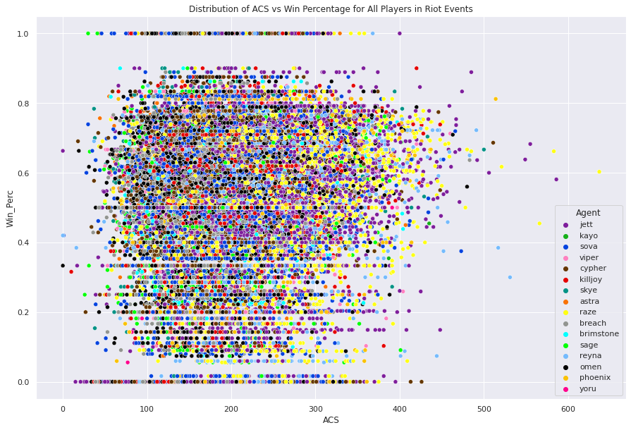

```python
sns.scatterplot(data=riotscores_trim, x="ACS", y="Win_Perc",hue="Agent",palette=new_palette,legend="full").set(title="Distribution of ACS vs Win Percentage for All Players in Riot Events")
sns.set(rc={"figure.figsize":(11, 11)})
plt.show()
```

This plot's way too messy, we can't glean much as there's too many points. But - there's some stuff to learn from this! If we look at points with ACS values at about 400 or greater, we can see that most of these points correspond to duelist agents. There's a multitude of Jetts, Razes, and Reynas out here. We can deduce that most of the highest ACS performances throughout these Riot events are done by duelists. They have the kit to take space and do damage, when combined with skilled players, they 're hard to stop.

We can also see immediately that there's a LOT of purple and yellow dots throughout this scatterplot - so many players love to play Jett and Raze. Jett has been critiqued as an easy agent to play and she's very powerful. In a game in VALORANT, movement is huge. Jett's kit is purely built around movement. She has an ability that lets her fly straight up and another one that lets her dash forward, covering a lot of ground instantly. However, not all players are built equal. Thata explains why we have Jetts all across the scatter plot - some players aren't that good but still play Jett. Raze is a high damage character - her kit involves a grenade, a rocket launcher, and two mini explosives. She's been critiqued as a "free kill" character as ability usage will inevitably lead to a kill. The furthest point on the ACS axis is a Raze with above 600 ACS. This is our friend berLIN vs ABC - just beating them into the dirt.

Matter of fact, let's find out just how many players played each agent throughout these events. I'd expect the duelist characters like Jett and Raze to have the highest frequency - except Yoru/Phoenix (they're really bad).

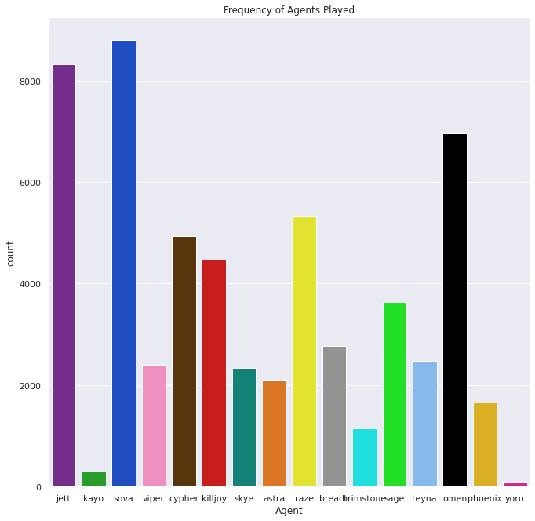

```python
sns.countplot(x=riotscores_trim['Agent'], palette=new_palette).set(title='Frequency of Agents Played')
sns.set(rc={"figure.figsize":(20, 13)})
plt.show()
```

Seems like my predication of duelist characters being the most played throughout the tournament was wrong. With our histogram, we can see that Sova (an initiator) was the most played agent throughout all of the events. Sova's kit is built around intelligence gathering - he has a drone, an area of effect scanning dart, and two shock darts that do damage. He seems to have been an essential pick as he has the highest pickrate. Jett is our close second however. More often than not, Jett was being picked as her abilities are incredibly strong. When watching VALORANT events, I recall that most teams played one duelist - always Jett. Our third most played agent is Omen. Omen is a controller agent whose kit consists of 2 smokes, 2 teleports, and a blind. He's a "smoking" agent, designed to throw smokes and obstruct enemy lines of sight. Our fourth most played is Raze, another duelist. The other duelists don't contribute much towards teamplay - they're more self-sufficient than others. That explains why they don't have incredible pick rates. As an example, Reyna's ability is purely selfish. She can flash for her team but her other abilities are self-heals and temporary self-invulnerability.

Here is a text listing of the same plot but with numbers to see the full ordering:

```python
riotscores_trim['Agent'].value_counts()
```

```
sova         8801
jett         8322
omen         6965
raze         5335
cypher       4940
killjoy      4471
sage         3632
breach       2776
reyna        2479
viper        2404
skye         2337
astra        2111
phoenix      1659
brimstone    1146
kayo          302
yoru          105
Name: Agent, dtype: int64
```

Our original scatterplot didn't tell us much as there was just way too much data being shown at once. We could somewhat see the frequency of agents, but let's create another plot to get a better visualization.

We'll condense this plot and create a plot that shows average ACS vs average win percentage **per** agent. This way we can see the average stats per character in the game. However, we have some outliers on both ends. Sometimes players play absolute scrubs, so their ACS is artifically high. An example would be berLIN's 637 ACS game. We also have the other end, those scrubs who get crushed, leaving their ACS artifically low. An example is ABC who got absolutely crushed by berLIN.

The same problem is present in the win percentages. Some players have a 100% win rate as they won every game they played. They may have been subbed out or dropped after a tournament/game. There are other players who play for fun and constantly lose, leaving them with a win percentage of 0%.

To avoid the impact of these outliers, we'll utilize the median ACS/Win Percentage as our average.

Now let's make our dataframe for the averages & create the graph.

```python
agent_groups = riotscores_trim.groupby(['Agent'])
agents = []
avg_acs = []
avg_winperc = []

for agent, agent_tbl in agent_groups:
    agents.append(agent)
    avg_acs.append(agent_tbl['ACS'].median())
    avg_winperc.append(agent_tbl['Win_Perc'].median())
```

```python
zipped = list(zip(agents,avg_acs, avg_winperc))
average_df = pd.DataFrame(zipped, columns=['Agent','AverageACS','AverageWinPerc'])
average_df.sort_values(by='AverageACS',ascending=True).reset_index().drop(['index'],axis=1, inplace=True)
average_df.head()
```

|  | Agent | AverageACS | AverageWinPerc |
| --- | --- | --- | --- |
| 0 | astra | 182.0 | 0.605263 |
| 1 | breach | 171.0 | 0.565217 |
| 2 | brimstone | 185.0 | 0.545455 |
| 3 | cypher | 185.0 | 0.560000 |
| 4 | jett | 225.0 | 0.576923 |

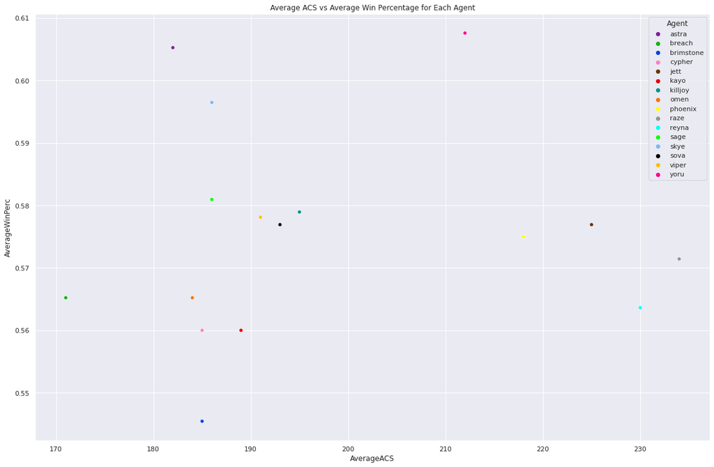

```python
sns.scatterplot(data=average_df, x='AverageACS', y='AverageWinPerc',hue='Agent',palette=new_palette).set(title="Average ACS vs Average Win Percentage for Each Agent")
sns.set(rc={"figure.figsize":(15, 10)})
plt.show()
```

Note: The colors changed for each agent because the list of agents is now being sorted alphabetically - **Jett is no longer purple!** Look at the legend!

Alright! Now we have something easy to read. This plot shows the Average ACS vs Average Win % per agent. Off the bat, let's talk about some points of interest. The furthest point along our x-axis is Raze. She has the highest average ACS with a win percentage of about 57%. This makes her an appealing agent to play as her damage capacity can completely shift the game. A win rate of 57% is relatively high, making her an appealing option for new players.

Reyna is our runner up along the x-axis. She can do massive damage to a team if the player is mechanically gifted. All a Reyna player needs to do is rack up kills, then they can either escape or heal fully. Her kit has huge potential for damage but relies on a little more skill than Raze. Her win % is a tad lower at about 56%. She's also a strong damaging character for new players to try.

Actually - we can notice a cluster of agents at the ACS threshold of about 215 and higher. Our agents here are the four main duelists - Phoenix, Jett, Reyna, and Raze. They have the highest average ACS. If any player is new and simply wants to get kills/do damage, a duelist is their best bet.

Let's shift our attention and discuss the high performers along the y-axis. Our agent with the highest win percentage is...Yoru?? Yoru was widely regarded as an awful agent at launch. He received a multitude of buffs/changes but his presence in the professional scene has remained minimal. However, at these tournaments, agents are used in cooperative ways. Maybe there was a certain team that utilized Yoru multiple times? Let's find these Yoru players within the dataframe.

```python
yoru = riotscores_trim[riotscores_trim['Agent'] == 'yoru']
yoru.sort_values(by="ACS", ascending=True).head()
```

|  | GameID | PlayerID | PlayerName | TeamAbbreviation | Agent | ACS | Kills | Deaths | Assists | PlusMinus | ADR | Wins | Lost | GamesPlayed | Win_Perc |
| --- | --- | --- | --- | --- | --- | --- | --- | --- | --- | --- | --- | --- | --- | --- | --- |
| 45836 | 45023 | 3655 | shéd | PLS | yoru | 77.0 | 4.0 | 16.0 | 1.0 | -12.0 | 73.0 | 1 | 17 | 18 | 0.055556 |
| 40125 | 43335 | 4133 | Lawrence | NOX | yoru | 77.0 | 3.0 | 13.0 | 1.0 | -10.0 | 39.0 | 23 | 19 | 42 | 0.547619 |
| 77867 | 28974 | 3157 | gaabxx | SHK | yoru | 78.0 | 4.0 | 18.0 | 6.0 | -14.0 | 55.0 | 33 | 21 | 54 | 0.611111 |
| 102701 | 17636 | 3726 | ethos | RFD | yoru | 82.0 | 3.0 | 16.0 | 2.0 | -13.0 | 50.0 | 1 | 6 | 7 | 0.142857 |
| 51179 | 41407 | 461 | Gray | SNG | yoru | 89.0 | 6.0 | 16.0 | 6.0 | -10.0 | 66.0 | 25 | 28 | 53 | 0.471698 |

It seems like Yoru players just fill a role within their team. They don't have to perform incredibly well within the ACS category to win. Their teamwork and strategy can result in a win. Who knew! I still don't recommend playing Yoru however.

Let's continue with our analysis of the scatterplot above, moving to the agent with the next average highest win percentage. This is Astra, another controller agent. Her kit revolves around strategically placing "stars" across the map. These stars can become stuns, move players, or even become smokes. Her skill ceiling is incredibly high, requiring players to be aware of all parts of the map. She thrives in an environment where teamplay is coordinated such as professional events. This explains why her average percentage is so high. A good Astra is a powerful agent and scary opponent. She's much lower on the x-axis, meaning her ACS potential isn't anywhere as high as our duelists. Her does not promote damage, properly fitting her in the controller role. Play Astra if you're committed to learning the ins & outs of her kit. A good Astra is terrifying.

Our last point of interest is Breach, who finds himself without an incredible win rate and performing relatively low in terms of ACS. Breach is an initiator, starting engagements for his team. His abilties include a flash, a stun, and a wall-piercing blast. His flashes are unique as they require a wall as a medium - this kit doesn't allow Breach to capitalize on his own utility. Rather, he flashes for his teammates as they can better take advantage of the timing. They can take engagements exactly when the flash hits while Breach would still be running up and closing ground. Breach is a suitable agent for those who don't want to engage but rather set up their team for success. His win rate is about 56.5% so if your team is somewhat coordinated, a Breach will thrive.

### Linear Regression on Each Agent's Scatter Plot

Let's take a closer look at the relationship between ACS and Win Percentage per Agent. We'll create scatterplots with a regression line for each agent. This'll allow us to see if there's any correlation between ACS and win_percentage.

We'll import stats here so we can obtain the co-efficients of each linear fit. I'll append the first 5 digits of the slope to the title for easy viewing. There will also be a table with each agent's slope, intercept, and p_value.

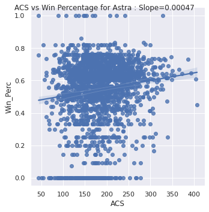

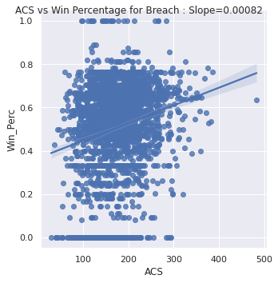

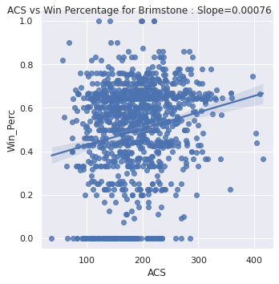

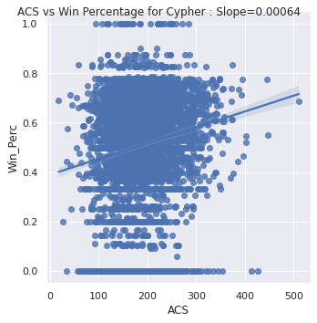

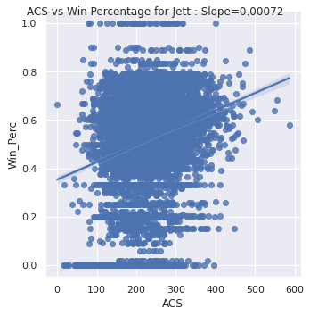

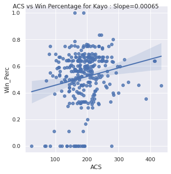

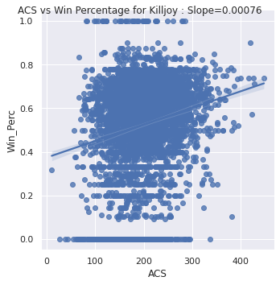

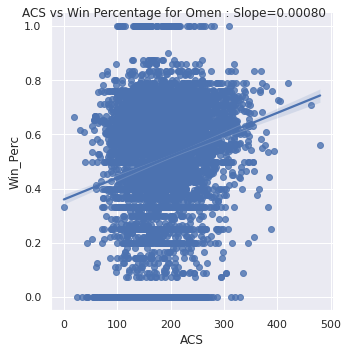

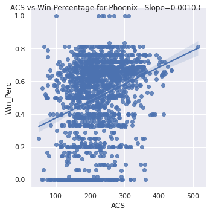

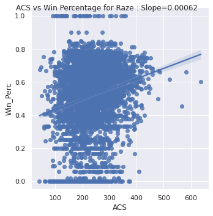

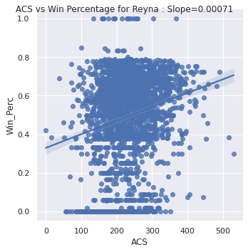

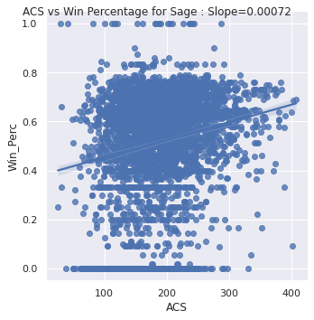

[4 more figures not shown]

```python
from scipy import stats

for agent, agent_tbl in agent_groups:
    slope, intercept, r_value, p_value, std_err = stats.linregress(agent_tbl['ACS'],agent_tbl['Win_Perc'])
    sns.lmplot(x="ACS", y="Win_Perc",data=agent_tbl).fig.suptitle("ACS vs Win Percentage for {} : Slope={:.5f}".format(agent[0].upper()+agent[1:],slope),fontsize=12)
```

Here's a table with each of the Agent's slopes for regression line, y-intercept, and the p-value for your viewing:

| Agent | Slope | Y-Intercept | P-Value |
| --- | --- | --- | --- |
| Astra | 0.00047491276844565837 | 0.4573393665647586 | 1.1230815195200086e-09 |
| Breach | 0.0008152573998307489 | 0.36556233957079604 | 1.606021927318641e-26 |
| Brimstone | 0.0007556581594202679 | 0.3526703019257756 | 4.321844345470005e-11 |
| Cypher | 0.0006401518142410093 | 0.3891447893247277 | 1.1006253892457092e-29 |
| Jett | 0.0007173292201109201 | 0.35335647048630114 | 9.766781329805578e-92 |
| KAY/O | 0.000650025132461758 | 0.3912987883342993 | 0.0014876925934630056 |
| Killjoy | 0.0007596748666591762 | 0.37403762537614965 | 7.451926604554767e-39 |
| Omen | 0.0008004982126143386 | 0.35983008732267197 | 1.2714396092600995e-61 |
| Phoenix | 0.001032531882809098 | 0.2721725821733856 | 3.5788471303280935e-32 |
| Raze | 0.000623233162718194 | 0.37099130516344636 | 1.4562166765528827e-47 |
| Reyna | 0.0007122351355357501 | 0.3290245608898058 | 1.381402135921342e-25 |
| Sage | 0.0007196097842692922 | 0.38133293538155155 | 1.4190625785291204e-32 |
| Skye | 0.0005250760675259258 | 0.4524951349470021 | 2.5893688274611798e-14 |
| Sova | 0.0005800439467025559 | 0.40065752285974937 | 1.814963887722762e-43 |
| Viper | 0.0004246990036624576 | 0.4489240826483416 | 2.7389273561342876e-09 |
| Yoru | 0.0008667257838125638 | 0.3832664550833279 | 0.0012947701352492877 |

### Hypothesis Testing/ML

In this final section of the tutorial, we'll attempt to develop a model that can accurately predict win percentage of a game based on ACS. We will be utilizing a **linear regression model**. We will split our data into a training set and a testing set to properly train it. We will also One-Hot Encode our agents so that our model will be able to process them.

One-Hot Encoding takes categorical variables such as agent names, and transforms them into numericals or something that can be processed by an algorithm.

```python
ml_df = riotscores_trim.copy()
ml_df = ml_df.drop(['GameID','PlayerID','PlayerName','TeamAbbreviation','Kills','Deaths','Assists','PlusMinus','ADR','Wins','Lost','GamesPlayed'], axis=1)
ml_df.head()
```

|  | Agent | ACS | Win_Perc |
| --- | --- | --- | --- |
| 4809 | jett | 178.0 | 0.627660 |
| 4810 | kayo | 170.0 | 0.533333 |
| 4811 | sova | 168.0 | 0.714286 |
| 4812 | viper | 144.0 | 0.729412 |
| 4813 | cypher | 120.0 | 0.714286 |

```python
# Source referenced: https://jiglesia3.github.io/
#utilized their R6S one-hot encoder - it's great
from sklearn.model_selection import train_test_split
from sklearn import preprocessing

def dummyEncode(df):
    # Filters through dataframe and recognizes categorical variables
    columnsToEncode = list(df.select_dtypes(include=['category','object']))
    le = preprocessing.LabelEncoder()
    for feature in columnsToEncode:
        try:
            df[feature] = le.fit_transform(df[feature])
        except:
            print('Error encoding '+feature)
    return df
```

Values of 1 or 0 for `Win_Perc` within our dataframe have potential to skew our results from the machine learning algorithm. We'll filter these values out within our `new encoded_df`.

```python
encoded_df = dummyEncode(ml_df)
zero_mask = (encoded_df['Win_Perc'] != 0)
encoded_df = encoded_df[zero_mask]

one_mask = (encoded_df['Win_Perc'] != 1)
encoded_df = encoded_df[one_mask]

encoded_df.sort_values(by='Win_Perc').head()
```

|  | Agent | ACS | Win_Perc |
| --- | --- | --- | --- |
| 90403 | 9 | 263.0 | 0.016393 |
| 85927 | 9 | 173.0 | 0.016393 |
| 85926 | 11 | 216.0 | 0.016393 |
| 100075 | 13 | 198.0 | 0.016393 |
| 127023 | 13 | 217.0 | 0.016393 |

Now, let's put together the pieces we need a machine learning algorithm. We're going to attempt to predict the win percentage based on ACS. ACS will be our x data, with win percentage acting as our y - the target. We'll split our data into training & testing sets, then train the model with our training sets. Afterward, we will run the trained model on our testing sets.

```python
x = encoded_df.drop(['Win_Perc'], axis = 1)
y = encoded_df.Win_Perc
X_train, X_test, y_train, y_test = train_test_split(x, y, test_size=0.3)
```

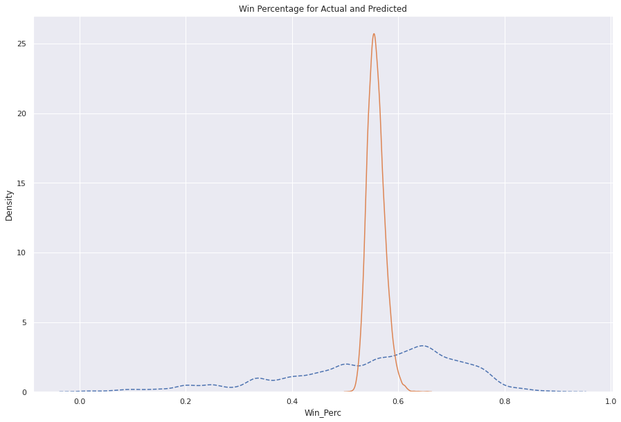

```python
from sklearn import linear_model

linreg = linear_model.LinearRegression().fit(X_train, y_train)
predicted_winrate = linreg.predict(X_test)
sns.kdeplot(y, linestyle='--')
sns.kdeplot(predicted_winrate)
plt.title("Win Percentage for Actual and Predicted")
plt.show()
```

Our actual win percentage is represented in the plot with the dotted line. The orange line is the win percentage which was predicted by the algorithm. It doesn't seem like our algorithm is correct. This model is unsuitable/insignificant for predicting the win percentage based on ACS for any agent. Maybe if the hyper-parameters were tweaked this would result in a more fitting model. We could also utilize another algorithm to create a correct production of win percentage based on ACS. Our current model is predicting values between .5 and .62 - there's no prediction below this.

### Conclusion

VALORANT is a complex game that's rising in popularity as months pass. It's being claimed as the successor to CS:GO. While the machine learning aspect of this tutorial was disappointing, I learned more about the agents and their capacity in professional matches. Learning that Astra has a low ACS but high winrate may make me try to play Astra more. I walked through most of the data science pipeline, showing the standard procedure that occurs on data. Tidying, exploration, and machine learning can be applied to every dataset/data science project.

I hope you learned something through reading this tutorial! Play VALORANT! Feel free to take this tutorial and make a properly working ML algorithm that gives more accurate predictions.